# Overview

These sections match the marking scheme. Each heading indicates the marks for each and type of content that should be included (either Markdown or Code). You can prepare markdown sections in Microsoft Word, but remember to change the cell type to 'Markdown' so the cell is not executed as code. (See: Markdown)

Rename the Notebook replacing the words 'KF7032_Template' with your user id (something like w12345678_KF7032) Before you submit the final version of your notebook, you should delete all output, and then run all cells. This checks that your program is consistent. Finally download the notebooks as an .ipynb file for assessment, and also as an html file that will readable by examiners who do not have Jupyter. Sections identified as Markdown should be at least one paragraph of text. The total word limit for markdown is 2500 words

# 1) Introduction: The Crime Analysis task ...*Markdown*, **10 Marks**, Max 300 Words

An essential area of research has always been a relationship between trends in crime and their underlying causes. The main goal of this study is to research the evaluation of violent crime trends, firearm-related incidents and their potential association with the drug offences in UK, especially in Liverpool. The research is centered on publicly available datasets from the English Indices of Deprivation and the UK Home Office. Detailed analysis of crime patterns has been rendered by these available databases, that offer extensive information about crime categories, their regional incidents and demographic characteristics.

This study has been inspired by the following claims made in the television documentary “Ross Kemp and the Armed Police”, which stated:

The rate of violent crime is increasing. In comparison to other UK locations, Liverpool experiences a higher number of firearm incidents per capita. Drug offences have a close correlation with firearm incidents. The main objective of this study is to assess and evaluate the validity of these claims using empirical data. The study provides empirical evidence into the veracity of these claims by analyzing firearm incidents per capita, time-series crime trends and analyzing the relationship between firearms and drugs.

In addition to evaluating the stated claims, this study seeks practical findings that could direct crime prevention measures. This study improves our knowledge and understanding of crime trends and their socio-geographical consequences in the UK.

# 2) Component Selection and Data Pipeline Implementation *code* **10 Marks**

In this section you will have one or more code cells. These will include your library imports. You will also access the data efficiently using Apache Spark on a cloud Infrastructure as a Service (IaaS) platform. (NB Google colab is SaaS -- not IaaS)

To speed your subsequent development you may want to initially use a subset of the data so could process that here.

```python
# Importing all necessary libraries

from pyspark.sql import SparkSession
from pyspark.sql.functions import year, month, count, regexp_replace, sum as _sum, col
from pyspark.sql import functions as F
import matplotlib.pyplot as plt
import pandas as pd
from IPython.display import display
import seaborn as sns
import geopandas as gpd
from shapely.geometry import Point
```

```python
# Initializing spark session
spark = SparkSession.builder.appName("WeaponsAndDrugs").getOrCreate()
print("Spark Session Initialized")
```

```
Spark Session Initialized
```

```python
#Importing Data

# `crime_data_path`: Path to the crime data file
# `population_data_path`: Path to the population data file
crime_data_path = r"/home/notebookuser/all_crimes21_hdr.txt"
population_data_path = r"/home/notebookuser/lsoa_pop.csv"

# Reading the crime data file
crime_data = spark.read.csv(crime_data_path, header=True, inferSchema=True)

# Reading the population data file
population_data = spark.read.csv(population_data_path, header=True, inferSchema=True)

# Displaying the schema and few rows of the crime data and population data
crime_data.printSchema()
crime_data.show(5)
population_data.printSchema()
population_data.show(5)
```

```
root
 |-- Crime ID: string (nullable = true)
 |-- Month: timestamp (nullable = true)
 |-- Reported by: string (nullable = true)
 |-- Falls within: string (nullable = true)
 |-- Longitude: double (nullable = true)
 |-- Latitude: double (nullable = true)
 |-- Location: string (nullable = true)
 |-- LSOA code: string (nullable = true)
 |-- LSOA name: string (nullable = true)
 |-- Crime type: string (nullable = true)
 |-- Last outcome category: string (nullable = true)
 |-- Context: string (nullable = true)

+--------+-------------------+--------------------+--------------------+---------+---------+--------------------+---------+--------------------+--------------------+---------------------+-------+
|Crime ID|              Month|         Reported by|        Falls within|Longitude| Latitude|            Location|LSOA code|           LSOA name|          Crime type|Last outcome category|Context|
+--------+-------------------+--------------------+--------------------+---------+---------+--------------------+---------+--------------------+--------------------+---------------------+-------+
|    NULL|2010-12-01 00:00:00|Avon and Somerset...|Avon and Somerset...|  -0.8056|51.819143|On or near Norfol...|E01017662| Aylesbury Vale 015C|         Other crime|                 NULL|   NULL|
|    NULL|2010-12-01 00:00:00|Avon and Somerset...|Avon and Somerset...|-2.494366|51.418169|On or near Keynsh...|E01014399|Bath and North Ea...|Anti-social behav...|                 NULL|   NULL|
|    NULL|2010-12-01 00:00:00|Avon and Somerset...|Avon and Somerset...|-2.511927|51.409435|On or near Harlec...|E01014399|Bath and North Ea...|Anti-social behav...|                 NULL|   NULL|
|    NULL|2010-12-01 00:00:00|Avon and Somerset...|Avon and Somerset...|-2.511571|51.414895|On or near Orchar...|E01014399|Bath and North Ea...|Anti-social behav...|                 NULL|   NULL|
|    NULL|2010-12-01 00:00:00|Avon and Somerset...|Avon and Somerset...|-2.511927|51.409435|On or near Harlec...|E01014399|Bath and North Ea...|Anti-social behav...|                 NULL|   NULL|
+--------+-------------------+--------------------+--------------------+---------+---------+--------------------+---------+--------------------+--------------------+---------------------+-------+
only showing top 5 rows

root
 |-- date: integer (nullable = true)
 |-- geography: string (nullable = true)
 |-- geography code: string (nullable = true)
 |-- Rural Urban: string (nullable = true)
 |-- Variable: All usual residents; measures: Value: integer (nullable = true)
 |-- Variable: Males; measures: Value: integer (nullable = true)
 |-- Variable: Females; measures: Value: integer (nullable = true)
 |-- Variable: Lives in a household; measures: Value: integer (nullable = true)
 |-- Variable: Lives in a communal establishment; measures: Value: integer (nullable = true)
 |-- Variable: Schoolchild or full-time student aged 4 and over at their non term-time address; measures: Value: integer (nullable = true)
 |-- Variable: Area (Hectares); measures: Value: double (nullable = true)
 |-- Variable: Density (number of persons per hectare); measures: Value: double (nullable = true)

+----+---------------+--------------+-----------+----------------------------------------------+--------------------------------+----------------------------------+-----------------------------------------------+------------------------------------------------------------+---------------------------…
|date|      geography|geography code|Rural Urban|Variable: All usual residents; measures: Value|Variable: Males; measures: Value|Variable: Females; measures: Value|Variable: Lives in a household; measures: Value|Variable: Lives in a communal establishment; measures: Value|Variable: Schoolchild or fu…
+----+---------------+--------------+-----------+----------------------------------------------+--------------------------------+----------------------------------+-----------------------------------------------+------------------------------------------------------------+---------------------------…
|2011|Darlington 001B|     E01012334|      Total|                                          2466|                            1220|                              1246|                                           2466|                                                           0|                           …
|2011|Darlington 001C|     E01012335|      Total|                                          1383|                             682|                               701|                                           1383|                                                           0|                           …
|2011|Darlington 001D|     E01012366|      Total|                                          2008|                             972|                              1036|                                           2008|                                                           0|                           …
|2011|Darlington 001E|     E01033481|      Total|                                          1364|                             680|                               684|                                           1350|                                                          14|                           …
|2011|Darlington 001F|     E01033482|      Total|                                          1621|                             810|                               811|                                           1621|                                                           0|                           …
+----+---------------+--------------+-----------+----------------------------------------------+--------------------------------+----------------------------------+-----------------------------------------------+------------------------------------------------------------+---------------------------…
only showing top 5 rows
```

# 3) Data Extraction and Filtering ... _code_includes System running, test and diagnostics, 10 Marks

1. Filter the dataset so that crimes refer to appropriate crimes only
2. To see whether crime cartegories are increasing, you will also need to extract them as a time series.

You should be using diagnostic checks throughout this report.

```python
# Filtering relevant crimes from the dataset
relevant_crimes = crime_data.filter(
    (crime_data['Crime type'] == "Violent crime") |
    (crime_data['Crime type'] == "Violence and sexual offences") |
    (crime_data['Crime type'] == "Possession of weapons") |
    (crime_data['Crime type'] == "Public disorder and weapons") |
    (crime_data['Crime type'] == "Drugs")
)


# Showing the first 10 rows of the filtered data
relevant_crimes.show(10)
```

```
+--------+-------------------+--------------------+--------------------+---------+---------+--------------------+---------+--------------------+-------------+---------------------+-------+
|Crime ID|              Month|         Reported by|        Falls within|Longitude| Latitude|            Location|LSOA code|           LSOA name|   Crime type|Last outcome category|Context|
+--------+-------------------+--------------------+--------------------+---------+---------+--------------------+---------+--------------------+-------------+---------------------+-------+
|    NULL|2010-12-01 00:00:00|Avon and Somerset...|Avon and Somerset...|-2.509773|51.405767|On or near Cedar ...|E01014402|Bath and North Ea...|Violent crime|                 NULL|   NULL|
|    NULL|2010-12-01 00:00:00|Avon and Somerset...|Avon and Somerset...|-2.497371|51.412906|On or near Temple...|E01014403|Bath and North Ea...|Violent crime|                 NULL|   NULL|
|    NULL|2010-12-01 00:00:00|Avon and Somerset...|Avon and Somerset...| -2.50326|51.410965|On or near Courtl...|E01014403|Bath and North Ea...|Violent crime|                 NULL|   NULL|
|    NULL|2010-12-01 00:00:00|Avon and Somerset...|Avon and Somerset...|-2.498987|51.406757|On or near Tamwor...|E01014404|Bath and North Ea...|Violent crime|                 NULL|   NULL|
|    NULL|2010-12-01 00:00:00|Avon and Somerset...|Avon and Somerset...|-2.483216|51.416346|On or near Broadm...|E01014396|Bath and North Ea...|Violent crime|                 NULL|   NULL|
|    NULL|2010-12-01 00:00:00|Avon and Somerset...|Avon and Somerset...|-2.483216|51.416346|On or near Broadm...|E01014396|Bath and North Ea...|Violent crime|                 NULL|   NULL|
|    NULL|2010-12-01 00:00:00|Avon and Somerset...|Avon and Somerset...|-2.483216|51.416346|On or near Broadm...|E01014396|Bath and North Ea...|Violent crime|                 NULL|   NULL|
|    NULL|2010-12-01 00:00:00|Avon and Somerset...|Avon and Somerset...|-2.475536|51.412124|On or near Pixash...|E01014398|Bath and North Ea...|Violent crime|                 NULL|   NULL|
|    NULL|2010-12-01 00:00:00|Avon and Somerset...|Avon and Somerset...|-2.345114|51.401467|On or near Rose Hill|E01014409|Bath and North Ea...|Violent crime|                 NULL|   NULL|
|    NULL|2010-12-01 00:00:00|Avon and Somerset...|Avon and Somerset...|-2.345526|51.398948|On or near Daffor...|E01014409|Bath and North Ea...|Violent crime|                 NULL|   NULL|
+--------+-------------------+--------------------+--------------------+---------+---------+--------------------+---------+--------------------+-------------+---------------------+-------+
only showing top 10 rows
```

```python
# Joining crime data with Population data
# Performing an inner join between the `relevant_crimes` dataset and the `population_data` dataset based on a common key: the LSOA code.
enhanced_data = relevant_crimes.join(
    population_data,
    relevant_crimes['LSOA code'] == population_data['geography code'],
    how="inner"
)

# Showing the first 5 rows of the enhanced dataset
enhanced_data.show(5)
```

```
+--------+-------------------+--------------------+--------------------+---------+---------+--------------------+---------+--------------------+-------------+---------------------+-------+----+--------------------+--------------+-----------+----------------------------------------------+------------…
|Crime ID|              Month|         Reported by|        Falls within|Longitude| Latitude|            Location|LSOA code|           LSOA name|   Crime type|Last outcome category|Context|date|           geography|geography code|Rural Urban|Variable: All usual residents; measures: Value|Variable: Ma…
+--------+-------------------+--------------------+--------------------+---------+---------+--------------------+---------+--------------------+-------------+---------------------+-------+----+--------------------+--------------+-----------+----------------------------------------------+------------…
|    NULL|2010-12-01 00:00:00|Avon and Somerset...|Avon and Somerset...|-2.509773|51.405767|On or near Cedar ...|E01014402|Bath and North Ea...|Violent crime|                 NULL|   NULL|2011|Bath and North Ea...|     E01014402|      Total|                                          1684|            …
|    NULL|2010-12-01 00:00:00|Avon and Somerset...|Avon and Somerset...|-2.497371|51.412906|On or near Temple...|E01014403|Bath and North Ea...|Violent crime|                 NULL|   NULL|2011|Bath and North Ea...|     E01014403|      Total|                                          1671|            …
|    NULL|2010-12-01 00:00:00|Avon and Somerset...|Avon and Somerset...| -2.50326|51.410965|On or near Courtl...|E01014403|Bath and North Ea...|Violent crime|                 NULL|   NULL|2011|Bath and North Ea...|     E01014403|      Total|                                          1671|            …
|    NULL|2010-12-01 00:00:00|Avon and Somerset...|Avon and Somerset...|-2.498987|51.406757|On or near Tamwor...|E01014404|Bath and North Ea...|Violent crime|                 NULL|   NULL|2011|Bath and North Ea...|     E01014404|      Total|                                          1669|            …
|    NULL|2010-12-01 00:00:00|Avon and Somerset...|Avon and Somerset...|-2.483216|51.416346|On or near Broadm...|E01014396|Bath and North Ea...|Violent crime|                 NULL|   NULL|2011|Bath and North Ea...|     E01014396|      Total|                                          1434|            …
+--------+-------------------+--------------------+--------------------+---------+---------+--------------------+---------+--------------------+-------------+---------------------+-------+----+--------------------+--------------+-----------+----------------------------------------------+------------…
only showing top 5 rows
```

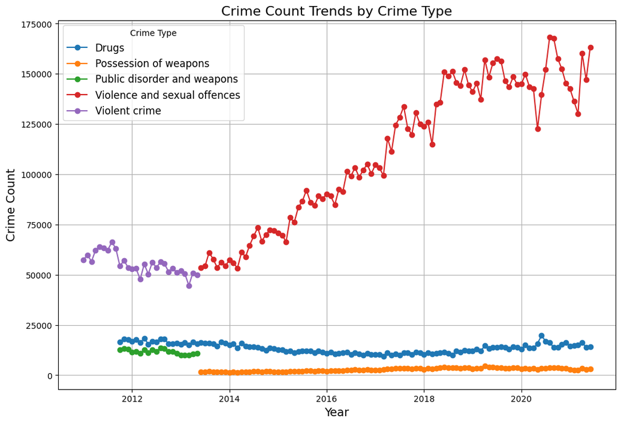

```python
# Extracting year and month from data
enhanced_data = enhanced_data.withColumn("year", year(col("Month")))
enhanced_data = enhanced_data.withColumn("month", month(col("Month")))

# Aggregating data for relevant crimes for time series analysis
time_series_data = enhanced_data.groupBy("year", "month", "Crime type").agg(count("*").alias("crime_count"))


# Converting to Pandas for Visualization
time_series_pd = time_series_data.select("year", "month", "Crime type", "crime_count").toPandas()

# Pivoting the data to have crime types as columns for easier plotting
pivoted_data = time_series_pd.pivot_table(
    index=["year", "month"],
    columns="Crime type",
    values="crime_count",
    aggfunc="sum"
).reset_index()

# Combining year and month for the x-axis
pivoted_data["date"] = pivoted_data["year"] + pivoted_data["month"] / 12

# Plotting all relevant crime types on a single chart
plt.figure(figsize=(12, 8))

for crime_type in pivoted_data.columns[2:-1]:
    plt.plot(
        pivoted_data["date"], pivoted_data[crime_type],
        marker="o",
        label=crime_type
    )

# Adding labels, title, and legend
plt.title("Crime Count Trends by Crime Type", fontsize=16)
plt.xlabel("Year", fontsize=14)
plt.ylabel("Crime Count", fontsize=14)
plt.legend(title="Crime Type", fontsize=12)
plt.grid()
plt.show()
```

# 4) Design, Development and reasoning behind use of multiple visualization methods, statistics, and machine learning Models, *markdown*, *code*, *markdown*, 20 Marks

The purpose of visualizations is to help identify relationships to investigate more formally, such as with statistics. Consequently you must explain your design choices. That is, what are you expecting to see in your graphics. Support your ideas using the literature.

**Analaysis of Claim 1: Violent crime is increasing**

Design Choice:

Filtering Datasets for relevant crime types: The dataset filetered with the "Violent crime" and "Violence and sexual offences". Filtering the specific categories in data is important as it increases the insights and interpretability of visualizations[1].

Expectation: By filtering the relevant crime categories, the trend graph will accurately show the targeted insights.

Use of Markers: The crime counf is marked each year with a marker to make data more readable and distinguishable. The Gestalt principle of proximity supports the usage of markers for precision and clear understanding, especially in datasets where particular annually patterns need to be visually identified[2].

Expectation: This will show the suddent increase or decrease in graph more accurately by representing yearly changes more clearly.

Chronological Sorting: The data has been sorted in a chronolgical manner which avoids the misinterpretation of pattern. Logical ordering (chronological for time-series data) is crucial for effective communication[3].

Expectation: This will enhance the visualization of the data by avoiding any confusion due to disorderly data.

```
+--------+-----+--------------------+--------------------+---------+---------+--------------------+---------+--------------------+-------------+---------------------+-------+----+--------------------+--------------+-----------+----------------------------------------------+--------------------------…
|Crime ID|month|         Reported by|        Falls within|Longitude| Latitude|            Location|LSOA code|           LSOA name|   Crime type|Last outcome category|Context|date|           geography|geography code|Rural Urban|Variable: All usual residents; measures: Value|Variable: Males; measures:…
+--------+-----+--------------------+--------------------+---------+---------+--------------------+---------+--------------------+-------------+---------------------+-------+----+--------------------+--------------+-----------+----------------------------------------------+--------------------------…
|    NULL|   12|Avon and Somerset...|Avon and Somerset...|-2.509773|51.405767|On or near Cedar ...|E01014402|Bath and North Ea...|Violent crime|                 NULL|   NULL|2011|Bath and North Ea...|     E01014402|      Total|                                          1684|                          …
|    NULL|   12|Avon and Somerset...|Avon and Somerset...|-2.497371|51.412906|On or near Temple...|E01014403|Bath and North Ea...|Violent crime|                 NULL|   NULL|2011|Bath and North Ea...|     E01014403|      Total|                                          1671|                          …
|    NULL|   12|Avon and Somerset...|Avon and Somerset...| -2.50326|51.410965|On or near Courtl...|E01014403|Bath and North Ea...|Violent crime|                 NULL|   NULL|2011|Bath and North Ea...|     E01014403|      Total|                                          1671|                          …
|    NULL|   12|Avon and Somerset...|Avon and Somerset...|-2.498987|51.406757|On or near Tamwor...|E01014404|Bath and North Ea...|Violent crime|                 NULL|   NULL|2011|Bath and North Ea...|     E01014404|      Total|                                          1669|                          …
|    NULL|   12|Avon and Somerset...|Avon and Somerset...|-2.483216|51.416346|On or near Broadm...|E01014396|Bath and North Ea...|Violent crime|                 NULL|   NULL|2011|Bath and North Ea...|     E01014396|      Total|                                          1434|                          …
+--------+-----+--------------------+--------------------+---------+---------+--------------------+---------+--------------------+-------------+---------------------+-------+----+--------------------+--------------+-----------+----------------------------------------------+--------------------------…
only showing top 5 rows
```

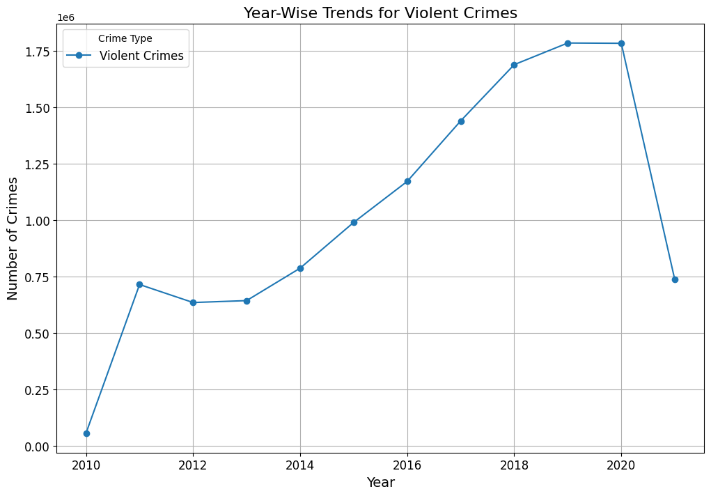

```python
# Filtering the violent crimes
violent_crimes = enhanced_data.filter(
    (enhanced_data['Crime type'] == "Violent crime")  |
    (enhanced_data['Crime type'] == "Violence and sexual offences")
)

# Showing the first 5 rows of the filtered dataset
violent_crimes.show(5)

# Grouping by Year and counting occurrences
violent_crime_trends = violent_crimes.groupBy("year").count()

# Converting the grouped data to a Pandas DataFrame for visualization
violent_crime_trends_pd = violent_crime_trends.toPandas()

# Sorting the data by Year to ensure chronological plotting order
violent_crime_trends_pd = violent_crime_trends_pd.sort_values(by=["year"])


# Setting up the plot
plt.figure(figsize=(12, 8))

# Plotting the trend for violent crimes
plt.plot(violent_crime_trends_pd['year'], violent_crime_trends_pd['count'], marker='o', label="Violent Crimes")

# Adding title and labels to the plot
plt.title("Year-Wise Trends for Violent Crimes", fontsize=16)
plt.xlabel("Year", fontsize=14)
plt.ylabel("Number of Crimes", fontsize=14)
plt.xticks(fontsize=12)
plt.yticks(fontsize=12)
plt.legend(title="Crime Type", fontsize=12)
plt.grid()

# Displaying the plot
plt.show()
```

**Area and Year wise violent crime (Top 15 Areas) -- showing increasing trend**

The visualizaton shows the pattern in violent crimes for the top 15 areas with the highest total crime counts annually. This will evaluate whether violent crime is increasing or decreasing over a particular period of time.

Design Choice:

Filtering Dataset: The dataset has been filetered out on the basis of Year and Area to calculate the yearly violent crimes for specific area. Identifying high-concentration zones and ranking is a standard approach in criminology[4].

Gridlines ad Titles: Gridlines helps in understanding data more clearly and to estimate the values more accurately. Titles and labels ensures visualization as self-explainatory. Tufte’s principles of effective visualization focuses on the importance of providing enough context to make the graph interpretable and clear[5].

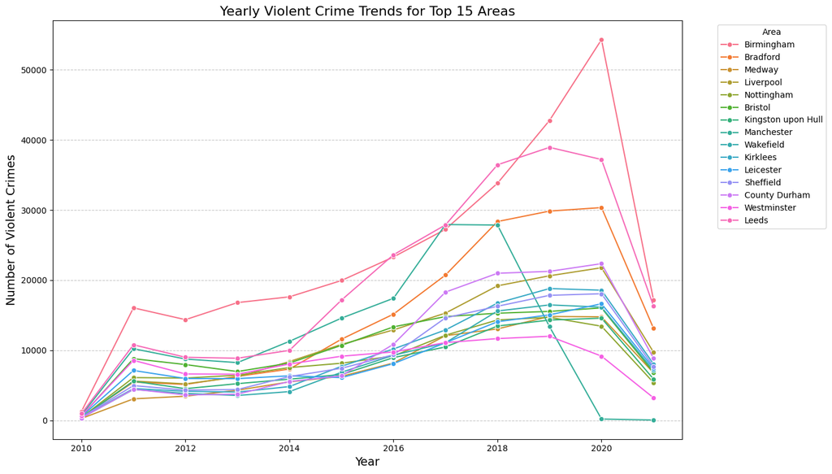

```python
violent_crimes = violent_crimes.withColumn(
    "Area", regexp_replace(col("geography"), r"\s\d+[A-Z]+$", "")
)

# Step 2: Group by Area and year to get year-based crime counts
violent_crimes_yearly = violent_crimes.groupBy("Area", "year").count()

# Step 3: Calculate total crimes for each area to identify the top 15

total_violent_crimes_by_area = violent_crimes_yearly.groupBy("Area").agg(
    _sum("count").alias("total_violent_crimes")
)
top_15_violent_areas = total_violent_crimes_by_area.orderBy(
    col("total_violent_crimes").desc()
).limit(15)

# Step 4: Filter year-based data to include only the top 15 areas
top_15_violent_area_names = [row["Area"] for row in top_15_violent_areas.collect()]
filtered_violent_crime_data = violent_crimes_yearly.filter(col("Area").isin(top_15_violent_area_names))

# Step 5: Convert to Pandas for visualization
filtered_violent_data_pd = filtered_violent_crime_data.toPandas()

# Step 6: Plot year-based crime trends for the top 15 areas

plt.figure(figsize=(14, 8))
sns.lineplot(
    data=filtered_violent_data_pd,
    x="year",
    y="count",
    hue="Area",
    marker="o"
)
plt.title("Yearly Violent Crime Trends for Top 15 Areas", fontsize=16)
plt.xlabel("Year", fontsize=14)
plt.ylabel("Number of Violent Crimes", fontsize=14)
plt.legend(title="Area", bbox_to_anchor=(1.05, 1), loc="upper left", fontsize=10)
plt.grid(axis="y", linestyle="--", alpha=0.7)
plt.tight_layout()
plt.show()
```

**Analysis of Claim 2: There are more firearms incidents per head in Liverpool than anywhere else in the UK**

The objective of this analysis to determine whether Liverpool has highest firearm incidents per head in the UK.

Design Choice:

Filtering Dataset: Incidents that are involved in firearm such as 'Possession of weapons' and 'Public disorder and weapons' has been filetered which improves data reliability for analysis[6].

Population Normalization: The firearm incidents are divided by the population of each area to calculate incidents per capita which makes the comparison more meaningful. It is standard method of normzalizing dataset for comparing crime rates across different areas of varying population sizes[7].

Ranking and Visualization: To compare incidents per head across areas, a bar chart has been used with a horizontal line indicating the national average. In the top 15 areas, Liverpool's ranking is shown for the firearm related incidents. Bar charts are useful for categorical comparisons for multiple regions [8].

```
+--------------------+----------------+
|                Area|Total Population|
+--------------------+----------------+
|           Worcester|           98768|
|           Charnwood|          166100|
|      North Kesteven|          107766|
|       Epping Forest|          124659|
|             Waveney|          115254|
|                Arun|          149518|
|              Stroud|          112779|
|              Maldon|           61629|
|          New Forest|          176462|
|           Sedgemoor|          114588|
|           Guildford|          137183|
|            Worthing|          104640|
|             Fareham|          111581|
|      North Tyneside|          200801|
|              Bolton|          276786|
|Central Bedfordshire|          254381|
|      Wellingborough|           75356|
|        Surrey Heath|           86144|
|              Slough|          140205|
|          Spelthorne|           95598|
+--------------------+----------------+
only showing top 20 rows

+--------------------+-----+----------------+--------------------+
|                Area|count|Total Population|  Incidents per Head|
+--------------------+-----+----------------+--------------------+
|           Worcester|   98|           98768|9.922242021707436E-4|
|      North Kesteven|    7|          107766|6.495555184380973E-5|
|       Epping Forest|   21|          124659|1.684595576733328...|
|              Stroud|    9|          112779|7.980209081477934E-5|
|           Guildford|   39|          137183|2.842917854253078E-4|
|Central Bedfordshire|   44|          254381|1.729688931170174E-4|
|              Bolton|   96|          276786|3.468383516507338E-4|
|              Slough|   56|          140205|3.994151421133340...|
|      Aylesbury Vale|   40|          174137|2.297041984184866E-4|
|         West Dorset|   11|           99264|1.108156028368794...|
|      Stoke-on-Trent|  161|          249008|6.465655721904517E-4|
|          Sunderland|  119|          275506|4.319325168961837...|
|        Chesterfield|   65|          103788| 6.26276640844799E-4|
|           High Peak|   27|           90892|2.970558464991418...|
|          Manchester|  357|          503127|7.095623967705967E-4|
+--------------------+-----+----------------+--------------------+
only showing top 15 rows
```

|  | Area | count | Total Population | Incidents per Head |
| --- | --- | --- | --- | --- |
| 178 | City of London | 28 | 7375 | 0.003797 |
| 98 | Westminster | 264 | 219396 | 0.001203 |
| 203 | Kingston upon Hull | 274 | 256406 | 0.001069 |
| 0 | Worcester | 98 | 98768 | 0.000992 |
| 165 | Nottingham | 290 | 305680 | 0.000949 |
| 63 | Derby | 213 | 248752 | 0.000856 |
| 191 | Middlesbrough | 118 | 138412 | 0.000853 |
| 110 | Torbay | 109 | 130959 | 0.000832 |
| 81 | Plymouth | 208 | 256384 | 0.000811 |
| 231 | North East Lincolnshire | 123 | 159616 | 0.000771 |
| 39 | Camden | 169 | 220338 | 0.000767 |
| 80 | Islington | 155 | 206125 | 0.000752 |
| 23 | Lambeth | 226 | 303086 | 0.000746 |
| 179 | Darlington | 76 | 105564 | 0.000720 |
| 148 | Liverpool | 334 | 466415 | 0.000716 |

```
Liverpool is ranked 15 among all areas.
```

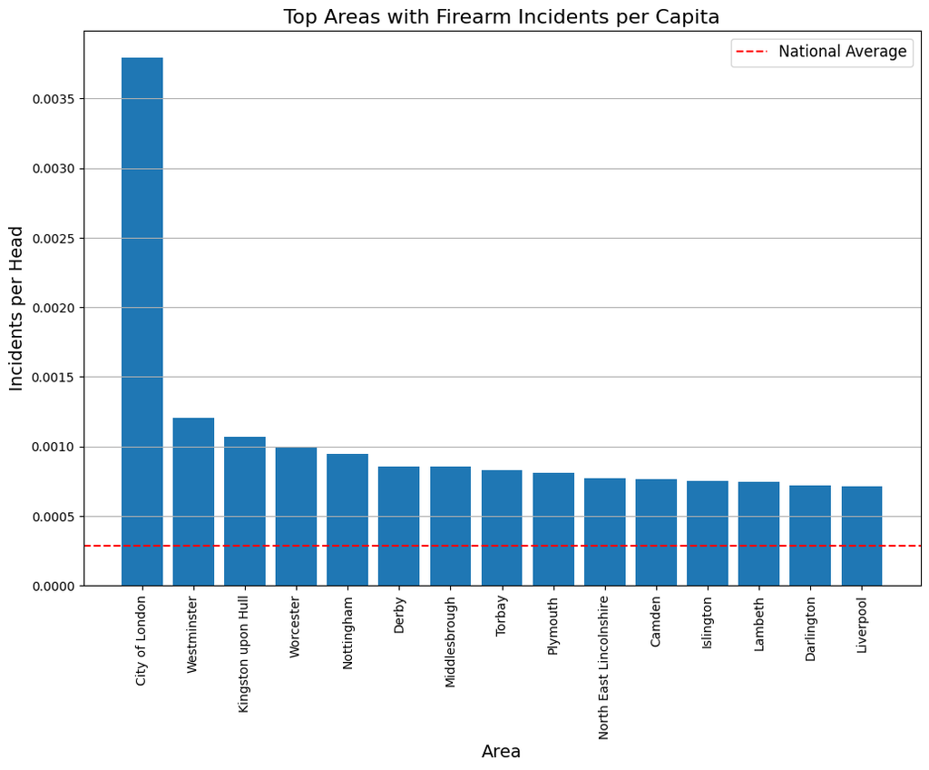

```python
# Filtering data for firearm incidents
firearm_incidents = enhanced_data.filter(
    (
        (enhanced_data['Crime type'] == 'Possession of weapons') |
        (enhanced_data['Crime type'] == 'Public disorder and weapons')
    ) &
    (enhanced_data['Last outcome category'] == 'Offender sent to prison')

)

# Extracting Area Names by removing suffix codes (e.g., '001A', '002A')
firearm_incidents = firearm_incidents.withColumn(
    "Area", regexp_replace(col("geography"), r"\s\d+[A-Z]+$", "")
)


# Grouping firearm incidents by area name and counting number of firearm incidents per area.
firearm_incidents_by_area = firearm_incidents.groupBy("Area").count()


# Extracting Area Name for population data
population_data = population_data.withColumn(
    "Area", regexp_replace(col("geography"), r"\s\d+[A-Z]+$", "")
)


# Aggregating population data by area and summing the total population for each area.
population_by_area = population_data.groupBy("Area").agg(
    _sum("Variable: All usual residents; measures: Value").alias("Total Population")
)

#  Displaying the aggregated population data for verification
population_by_area.show()

# Joinning firearm incidents and population data
firearm_per_capita = firearm_incidents_by_area.join(
    population_by_area, on="Area", how="inner"
)

# Calculating incidents per capita
# Adding a new column "Incidents per Head" by dividing the count of incidents by the total population for each area.
firearm_per_capita = firearm_per_capita.withColumn(
    "Incidents per Head", col("count") / col("Total Population")
)

# Displaying the results to verify the calculation
firearm_per_capita.show(15)

# Converting to Pandas for visualization
firearm_per_capita_pd = firearm_per_capita.toPandas()

# Sorting the data by "Incidents per Head" in descending order for ranking and visualization
firearm_per_capita_pd = firearm_per_capita_pd.sort_values(by="Incidents per Head", ascending=False)

# Extract the top 15 areas with the highest incidents per capita
top_15_areas = firearm_per_capita_pd.head(15)
display(top_15_areas)

# Adding a rank column to the DataFrame based on "Incidents per Head" (descending order)
firearm_per_capita_pd["Rank"] = firearm_per_capita_pd["Incidents per Head"].rank(method="min", ascending=False)

# Getting Liverpool's rank
liverpool_rank = firearm_per_capita_pd[firearm_per_capita_pd["Area"] == "Liverpool"]['Rank'].iloc[0]

# Printing Liverpool's rank
print(f"Liverpool is ranked {int(liverpool_rank)} among all areas.")

# Calculating national average incidents per capita
national_average = firearm_per_capita_pd["Incidents per Head"].mean()

# Highlighting Liverpool's data for comparison
liverpool_data = firearm_per_capita_pd[firearm_per_capita_pd["Area"] == "Liverpool"]

# Adding Liverpool to the top areas if not already included
if "Liverpool" not in top_15_areas["Area"].values:
    top_15_areas = pd.concat([top_15_areas, liverpool_data]).reset_index(drop=True)
    display(top_15_areas)

# Plotting the results
plt.figure(figsize=(12, 8))
plt.bar(top_15_areas["Area"], top_15_areas["Incidents per Head"])
plt.axhline(y=national_average, color='red', linestyle='--', label="National Average")
plt.title("Top Areas with Firearm Incidents per Capita", fontsize=16)
plt.xlabel("Area", fontsize=14)
plt.ylabel("Incidents per Head", fontsize=14)
plt.xticks(rotation=90, fontsize=10)
plt.legend(fontsize=12)
plt.grid(axis="y")

# Displaying the plot
plt.show()
```

**Analysis of Claim 3: Crimes involving firearms are closely associated with drugs offences**

The aim of this analysis is to find the proportion of firearm-related incidents which are linked to drug possessione warnings which will test the claim that "crimes involving firearms are closely associated with drug offences".

```python
# Filtering for firearm-related incidents
overall_firearm_incidents = enhanced_data.filter(
        (enhanced_data['Crime type'] == 'Possession of weapons') |
        (enhanced_data['Crime type'] == 'Public disorder and weapons')
)

#Filtering for firearm-related incidents that are associated with drugs possession
firearm_incidents_related_with_drugs = enhanced_data.filter(
    (
        (enhanced_data['Crime type'] == 'Possession of weapons') |
        (enhanced_data['Crime type'] == 'Public disorder and weapons')
) &
        (enhanced_data['Last outcome category'] == 'Offender given a drugs possession warning')

)

#Total number of firearm-related incidents
total_firearm_incidents = overall_firearm_incidents.count()

#Total number of firearm-related incidents that are associated with drugs possession
total_firearm_incidents_related__with_drugs = firearm_incidents_related_with_drugs.count()

# Proportion of firearm-related incidents that are associated with drugs possession
proportion_with_drugs = total_firearm_incidents_related__with_drugs / total_firearm_incidents

# Represents the fraction of firearm-related incidents linked to drugs possession out of the total firearm incidents
print(f"Percentage of firearms crime which are linked with Drugs is {(proportion_with_drugs * 100)} %.")
```

```
Percentage of firearms crime which are linked with Drugs is 0.16101553232650526 %.
```

The result shows that only 0.16% of firearm realted incidents are linked with drug offences. This shows a weak relation between firearm incidents and drug offences.

**Correlation analysis based on geography**

The analysis evaluates the connection between drug related and firearm related incidents using correlation analysis which will determine whether areas with higher related drug crimes also have higher firearm incidents.

```
Correlation coefficient (Pearson) between drug and firearm crimes by geography: 0.69
```

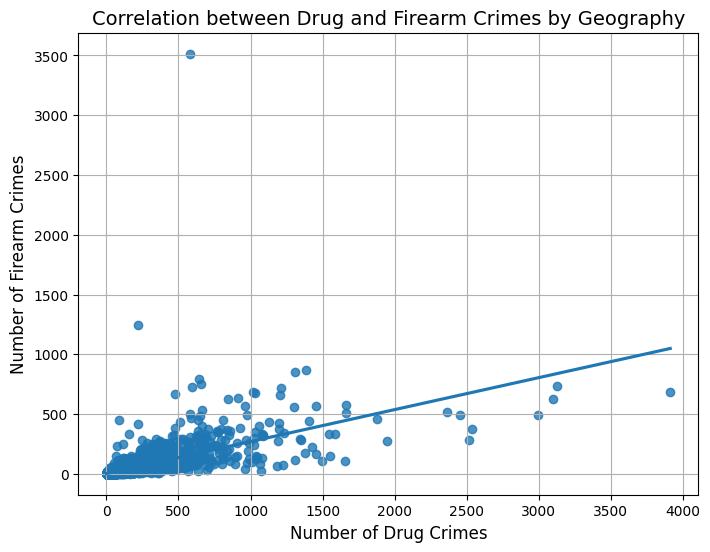

```python
# Aggregatting drug and firearm crimes by geography ("LSOA code")
drug_data = enhanced_data.filter(col("Crime type") == "Drugs")
drug_counts = drug_data.groupBy("LSOA code").agg(F.count("*").alias("Drug_Crimes"))

firearm_counts = overall_firearm_incidents.groupBy("LSOA code").agg(F.count("*").alias("Firearm_Crimes"))

# Joining the two datasets on the geographical key
correlation_data_firearm_drugs = drug_counts.join(firearm_counts, on="LSOA code", how="inner")

# Converting to Pandas for easier analysis
correlation_df = correlation_data_firearm_drugs.toPandas()

# Calculate correlation coefficient (Pearson)
correlation_value = correlation_df['Drug_Crimes'].corr(correlation_df['Firearm_Crimes'])

print(f"Correlation coefficient (Pearson) between drug and firearm crimes by geography: {correlation_value:.2f}")

# Visualization: Scatter Plot with Regression Line
plt.figure(figsize=(8, 6))
sns.regplot(x="Drug_Crimes", y="Firearm_Crimes", data=correlation_df, ci=None)
plt.title("Correlation between Drug and Firearm Crimes by Geography", fontsize=14)
plt.xlabel("Number of Drug Crimes", fontsize=12)
plt.ylabel("Number of Firearm Crimes", fontsize=12)
plt.grid(True)
plt.show()
```

The correlation coefficient (Pearson) of 0.69 indicates a moderately strong positive correlation between drug-related crimes and firearm-related crimes across different geographies. This suggests that regions with higher drug-related crimes also tend to experience higher firearm-related crimes.

**Trend Analysis: Analyze trends over time to see if the association between firearms and drugs offenses has changed.**

The aim of this analysis is to find the changes in relationship between firearm incidents and drug related incidents over time. Analysis of trends in firearm incidents linked to drug and comparison of pattern in firearm offences with drug offences over the years was shown.

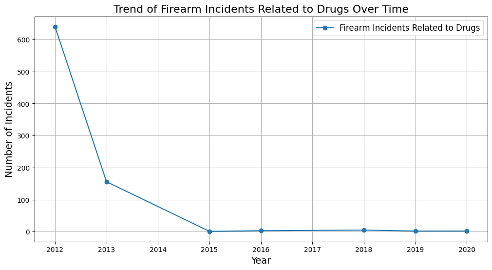

```python
# Grouping by year and count incidents
firearm_drug_trends = firearm_incidents_related_with_drugs.groupBy("year").agg(
    count("*").alias("Incidents")
)

# Converting to Pandas for visualization
firearm_drug_trends_pd = firearm_drug_trends.toPandas().sort_values(by="year")


plt.figure(figsize=(12, 6))
plt.plot(
    firearm_drug_trends_pd["year"],
    firearm_drug_trends_pd["Incidents"],
    marker="o",
    label="Firearm Incidents Related to Drugs"
)
plt.title("Trend of Firearm Incidents Related to Drugs Over Time", fontsize=16)
plt.xlabel("Year", fontsize=14)
plt.ylabel("Number of Incidents", fontsize=14)
plt.grid()
plt.legend(fontsize=12)
plt.show()
```

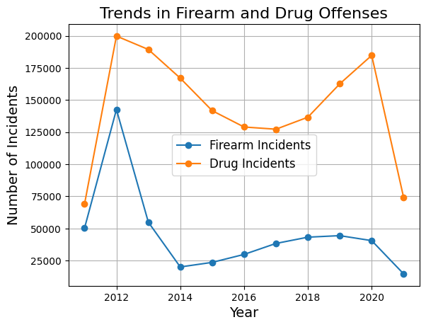

```python
# Extracting year for firearm incidents
firearm_trends = overall_firearm_incidents.groupBy("year").agg(
    count("*").alias("Firearm_Incidents")
)

# Extracting year for drug incidents
drug_data = enhanced_data.filter(col("Crime type") == "Drugs")
drug_trends = drug_data.groupBy("year").agg(
    count("*").alias("Drug_Incidents")
)

# Extracting year for co-occurring firearm and drug incidents
firearm_drug_trends = enhanced_data.filter(
    (col("Crime type") == "Possession of weapons") | (col("Crime type") == "Public disorder and weapons") | (col("Crime type") == "Drugs")
).groupBy("year").agg(
    count("*").alias("Firearm_and_Drug_Incidents")
)

# Combining all trends
trends = firearm_trends.join(drug_trends, on="year", how="outer").join(
    firearm_drug_trends, on="year", how="outer"
).fillna(0)


# Converting to Pandas DataFrame for visualization
trends_pd = trends.toPandas()
trends_pd = trends_pd.sort_values(by="year")

# Plotting Firearm Incidents
plt.plot(trends_pd["year"], trends_pd["Firearm_Incidents"], marker="o", label="Firearm Incidents")

# Plot Drug Incidents
plt.plot(trends_pd["year"], trends_pd["Drug_Incidents"], marker="o", label="Drug Incidents")


# Add titles and labels
plt.title("Trends in Firearm and Drug Offenses", fontsize=16)
plt.xlabel("Year", fontsize=14)
plt.ylabel("Number of Incidents", fontsize=14)
plt.grid()
plt.legend(fontsize=12)
plt.show()
```

The trend analysis of firearm incidents linked to drugs shows the number of firearm incidents linked to drugs has almost disappeared after 2015. This change might be due to the handling of crime by law enforcement agencies. Moreover, the second graph shows that the drug incidents were highest in 2012 and consistent decreased till 2016. Overall, the graph does not show the close relation between firearm and drug related incidents.

# 5) Selection, application, and reasoning behind use of statistical analysis and multiple evaluation measures *markdown*, *code*, *markdown*, 20 Marks

As in the previous section,

1. Explain what you are trying to do (with references)
2. Do the coding and include the results
3. Explain your findings.

CLAIM-1 **Seasonality Analysis: Analyse whether violent crimes exhibit seasonal patterns (e.g., spikes in summer or holidays).**

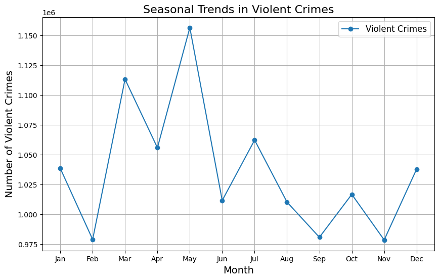

```python
# Filtering for violent crimes
violent_crimes = enhanced_data.filter(
    (enhanced_data["Crime type"] == "Violent crime") |
    (enhanced_data["Crime type"] == "Violence and sexual offences")
)

# Grouping by Month and count incidents
monthly_trends = violent_crimes.groupBy("month").agg(
    count("*").alias("Violent_Incidents")
)

# Converting to Pandas for visualization
monthly_trends_pd = monthly_trends.toPandas()
monthly_trends_pd = monthly_trends_pd.sort_values(by="month")


plt.figure(figsize=(10, 6))
plt.plot(
    monthly_trends_pd["month"],
    monthly_trends_pd["Violent_Incidents"],
    marker="o", label="Violent Crimes"
)
plt.xticks(range(1, 13), [
    "Jan", "Feb", "Mar", "Apr", "May", "Jun",
    "Jul", "Aug", "Sep", "Oct", "Nov", "Dec"
])
plt.title("Seasonal Trends in Violent Crimes", fontsize=16)
plt.xlabel("Month", fontsize=14)
plt.ylabel("Number of Violent Crimes", fontsize=14)
plt.legend(fontsize=12)
plt.grid()
plt.show()
```

In the visualization, seasonsal peaks can be seen. In the month of May, there is a noticeable peak in crime rates which could be a factor of increase in outdoor activites or public gatherings. February, Sep and Novemebr month shows the lowest crime rates which could be due to cold weather across the region. Overall, the graph suggests that external factors such as holidays, weather influence the number of violent crimes.

CLAIM-2 **Are firearm incidents concentrated in specific neighborhoods or spread across Liverpool ?**

The prupose of this visualizatoin is to determine the spatial distribution of firearm incidents in Liverpool. This will provide more deeper insights in understanding whether incidents are concentrated in specific regions and disperesed across the city as recommended by geospatial analysis best practices (e.g., "GIS for Crime Analysis" by Chainey and Ratcliffe)[10].

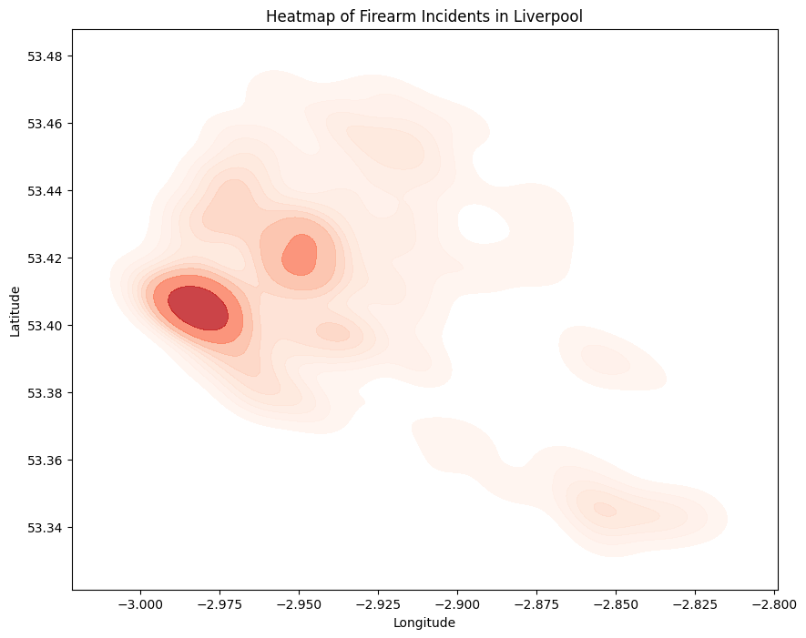

```python
# Filtering firearm incidents for Liverpool
liverpool_firearm_incidents = firearm_incidents.filter(
    firearm_incidents["Area"] == "Liverpool"
)

# Extracting latitude and longitude for heatmap visualization
liverpool_firearm_locations = liverpool_firearm_incidents.select("Latitude", "Longitude")

# Converting the data to Pandas for visualization
liverpool_firearm_pd = liverpool_firearm_locations.toPandas()

# Plotting the heatmap
plt.figure(figsize=(10, 8))
sns.kdeplot(
    x=liverpool_firearm_pd["Longitude"],
    y=liverpool_firearm_pd["Latitude"],
    cmap="Reds",
    fill=True,
    bw_adjust=0.5,
    alpha=0.8
)
plt.title("Heatmap of Firearm Incidents in Liverpool")
plt.xlabel("Longitude")
plt.ylabel("Latitude")
plt.show()
```

The visualization clearly shows that the firearm incidents are not spread across Liverpool. The incidents are occurring majorly in central Liverpool and few surrouding areas. Some smaller hotspots can be seen on the outskirts which might indicate the spillover from central neighbourhoods.

CLAIM-3 Differentiated Visualization for Drugs and Firearms based on lat & longitude

This aims to analyze the geospatial analysis of drug and firearm related crimes across the region. The pattern of relationship between the locations can be observed by plotting crime types using their latitudes and longitudes data which will evaluate whether crimes occurring over specific area, this approach tailored for handling geographic coordinates[11].

```
+--------+-----+--------------------+--------------------+---------+---------+--------------------+---------+--------------------+----------+---------------------+-------+----+--------------------+--------------+-----------+----------------------------------------------+-----------------------------…
|Crime ID|month|         Reported by|        Falls within|Longitude| Latitude|            Location|LSOA code|           LSOA name|Crime type|Last outcome category|Context|date|           geography|geography code|Rural Urban|Variable: All usual residents; measures: Value|Variable: Males; measures: Va…
+--------+-----+--------------------+--------------------+---------+---------+--------------------+---------+--------------------+----------+---------------------+-------+----+--------------------+--------------+-----------+----------------------------------------------+-----------------------------…
|    NULL|    9|Avon and Somerset...|Avon and Somerset...|   -2.507|51.408557|On or near Tenby ...|E01014404|Bath and North Ea...|     Drugs|                 NULL|   NULL|2011|Bath and North Ea...|     E01014404|      Total|                                          1669|                             …
|    NULL|    9|Avon and Somerset...|Avon and Somerset...|-2.492186|51.413386|On or near Dragon...|E01014396|Bath and North Ea...|     Drugs|                 NULL|   NULL|2011|Bath and North Ea...|     E01014396|      Total|                                          1434|                             …
|    NULL|    9|Avon and Somerset...|Avon and Somerset...|-2.483019|51.412705|On or near Bath Road|E01014398|Bath and North Ea...|     Drugs|                 NULL|   NULL|2011|Bath and North Ea...|     E01014398|      Total|                                          1423|                             …
|    NULL|    9|Avon and Somerset...|Avon and Somerset...|-2.392587|  51.3972|On or near Harcou...|E01014480|Bath and North Ea...|     Drugs|                 NULL|   NULL|2011|Bath and North Ea...|     E01014480|      Total|                                          1261|                             …
|    NULL|    9|Avon and Somerset...|Avon and Somerset...| -2.36158|51.384073|On or near Milsom...|E01014370|Bath and North Ea...|     Drugs|                 NULL|   NULL|2011|Bath and North Ea...|     E01014370|      Total|                                          1800|                             …
|    NULL|    9|Avon and Somerset...|Avon and Somerset...|-2.360317| 51.38431|On or near Broad ...|E01014370|Bath and North Ea...|     Drugs|                 NULL|   NULL|2011|Bath and North Ea...|     E01014370|      Total|                                          1800|                             …
|    NULL|    9|Avon and Somerset...|Avon and Somerset...|  -2.3623|51.380654|On or near Westga...|E01014370|Bath and North Ea...|     Drugs|                 NULL|   NULL|2011|Bath and North Ea...|     E01014370|      Total|                                          1800|                             …
|    NULL|    9|Avon and Somerset...|Avon and Somerset...|-2.360317| 51.38431|On or near Broad ...|E01014370|Bath and North Ea...|     Drugs|                 NULL|   NULL|2011|Bath and North Ea...|     E01014370|      Total|                                          1800|                             …
|    NULL|    9|Avon and Somerset...|Avon and Somerset...|-2.360317| 51.38431|On or near Broad ...|E01014370|Bath and North Ea...|     Drugs|                 NULL|   NULL|2011|Bath and North Ea...|     E01014370|      Total|                                          1800|                             …
|    NULL|    9|Avon and Somerset...|Avon and Somerset...|-2.352659|51.384442|On or near Edward...|E01014371|Bath and North Ea...|     Drugs|                 NULL|   NULL|2011|Bath and North Ea...|     E01014371|      Total|                                          1866|                             …
+--------+-----+--------------------+--------------------+---------+---------+--------------------+---------+--------------------+----------+---------------------+-------+----+--------------------+--------------+-----------+----------------------------------------------+-----------------------------…
only showing top 10 rows

+--------+-----+--------------------+--------------------+---------+---------+--------------------+---------+--------------------+--------------------+---------------------+-------+----+--------------------+--------------+-----------+----------------------------------------------+-------------------…
|Crime ID|month|         Reported by|        Falls within|Longitude| Latitude|            Location|LSOA code|           LSOA name|          Crime type|Last outcome category|Context|date|           geography|geography code|Rural Urban|Variable: All usual residents; measures: Value|Variable: Males; me…
+--------+-----+--------------------+--------------------+---------+---------+--------------------+---------+--------------------+--------------------+---------------------+-------+----+--------------------+--------------+-----------+----------------------------------------------+-------------------…
|    NULL|    9|Avon and Somerset...|Avon and Somerset...|-2.361416|51.381448|On or near Westga...|E01014370|Bath and North Ea...|Public disorder a...|                 NULL|   NULL|2011|Bath and North Ea...|     E01014370|      Total|                                          1800|                   …
```

[output cut: 11 more lines]

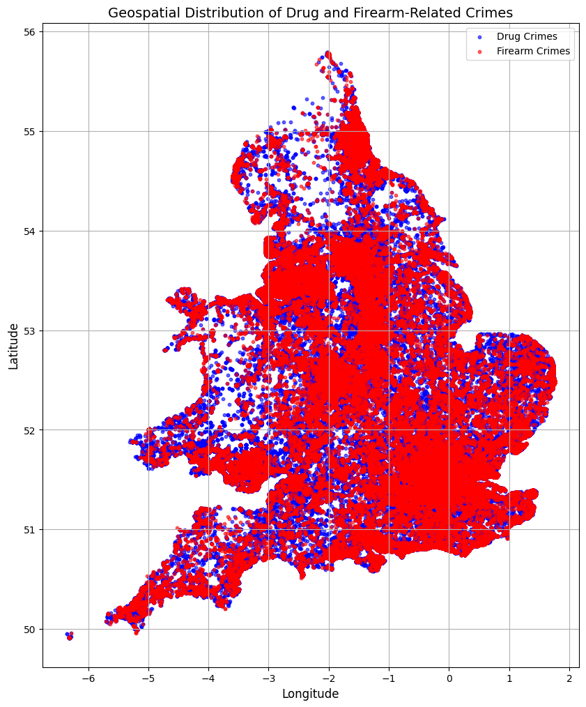

```python
# Showing already processed drugs & firearm data
drug_data.show(10)
overall_firearm_incidents.show(10)

# Selecting Latitude & Longitude data for drug & firearm crimes
drug_crime_locations = drug_data.select("Latitude", "Longitude")
firearm_crime_locations = overall_firearm_incidents.select("Latitude", "Longitude")

# Converting to pandas for better visualization
drug_crime_locations_pd = drug_crime_locations.toPandas()
firearm_crime_locations_pd = firearm_crime_locations.toPandas()

# Creating GeoDataFrames for drugs and firearms
drug_crime_locations_pd['geometry'] = drug_crime_locations_pd.apply(
    lambda row: Point(row['Longitude'], row['Latitude']), axis=1
)
firearm_crime_locations_pd['geometry'] = firearm_crime_locations_pd.apply(
    lambda row: Point(row['Longitude'], row['Latitude']), axis=1
)

geo_drugs = gpd.GeoDataFrame(drug_crime_locations_pd, geometry='geometry', crs="EPSG:4326")
geo_firearms = gpd.GeoDataFrame(firearm_crime_locations_pd, geometry='geometry', crs="EPSG:4326")

# Plotting the geospatial distribution
fig, ax = plt.subplots(figsize=(12, 12))

# Plot drugs and firearms on the same map
geo_drugs.plot(ax=ax, markersize=10, alpha=0.6, color="blue", label="Drug Crimes")
geo_firearms.plot(ax=ax, markersize=10, alpha=0.6, color="red", label="Firearm Crimes")

# Enhancing the plot
ax.set_title("Geospatial Distribution of Drug and Firearm-Related Crimes", fontsize=14)
ax.set_xlabel("Longitude", fontsize=12)
ax.set_ylabel("Latitude", fontsize=12)
ax.legend(fontsize=10)
plt.grid(True)

# Showing the plot
plt.show()
```

# 6) Detailed Analysis and consideration of the appropriateness of the solution for the initial problem *markdown*, 10 Marks

This is the discussion section of you report. You should critically consider the advantages, disadvantages, and limitations of the methods used.

### Advantages

**Scalability and Efficiency:**

The use of Apache Spark allowed efficient processing of large datasets containing millions of crime records. Its distributed computing framework significantly reduced computational time, enabling analysis that would have been infeasible with traditional methods.

**Comprehensive Analysis:**

The combination of multiple datasets (e.g., crime data and population data) provided a holistic perspective, allowing for per capita analysis and deeper insights into trends such as firearm incidents in Liverpool.

**Visualization for Insights:**

**Data-Driven Validation:**

The statistical correlation analysis provided a data-backed evaluation of the relationship between firearms and drug offenses, enabling an objective assessment of Claim 3.

**Replicability:**

The methods used, including Python-based data pipelines and statistical techniques, are well-documented and replicable, ensuring reproducibility for further analysis or validation.

### Disadvantages

**Assumptions in Data Interpretation:**

Certain assumptions, such as equating "Possession of weapons" crimes with firearm-related incidents, may not hold true for all cases, potentially leading to biased results.

**Visualization Bias:**

While visualizations are powerful tools, they are prone to subjective interpretation, especially when identifying patterns like hotspots or trends.

**Data Cleaning Challenges:**

Handling missing or inconsistent data (e.g., missing latitude/longitude values) was time-consuming and could introduce biases if certain records were excluded.

**Limitations**

**Data Quality:**

The datasets used may contain inaccuracies, such as reporting errors or incomplete data entries. This can affect the reliability of conclusions drawn from the analysis.

**Geographical and Temporal Granularity:**

**Causation vs. Correlation:**

The study identifies correlations between firearm-related incidents and drug offenses but cannot establish causation due to the absence of detailed contextual data.

**Generalizability:**

The findings are specific to the UK and the datasets used. Generalizing results to other regions or contexts requires caution.

**Demographic Limitations:**

Limited demographic data restricted the ability to assess how crimes disproportionately impact specific population subgroups, such as gender or socioeconomic classes.

# 7) Evaluation and Conclusion *markdown*, 10 Marks

In the conclusion you should consider you initial aim and objectives and discuss your findings. Specifically you need to advice your client insurance company.

This study aimed to evaluate the validity of three claims made in the documentary “Ross Kemp and the Armed Police”. Using publicly available data and advanced data analytics techniques, the findings for each claim are summarized below:

**Claim 1: Violent Crime is Increasing**

Evaluation:

While the analysis supports the claim that violent crime increased for a significant period, the decline in recent years complicates the claim's blanket validity.

**Claim 2: There Are More Firearm Incidents Per Head in Liverpool Than Anywhere Else in the UK**

Conclusion:

The claim that "Liverpool has the highest firearm incidents per head in the UK" is false. While firearm incidents in Liverpool are concerning, they are neither the highest nor evenly distributed across the city.

**Claim 3: Firearm Incidents Are Closely Associated with Drug Offenses**

Conclusion:

**Overall Conclusion**

# 8) References and Citation *markdown*, 10 Marks

References are essential at level 7. in this section you should give references for the papers/books you have cited in this assignment. Try to avoid using web pages as these are considered *weak references* as they are often not reviewed.

[1] C. Beckham, M. Hall, and E. Frank, ‘WekaPyScript: Classification, Regression, and Filter Schemes for WEKA Implemented in Python’, J Open Res Softw, vol. 4, no. 1, p. 33, Aug. 2016, doi: 10.5334/jors.108.

[2] ‘Shelia Guberman’, 2015.

[3] C. B. Ramsey, M. Blaauw, R. Kearney, and R. A. Staff, ‘The importance of open access to chronological information: The intchron initiative’, Radiocarbon, vol. 61, no. 5, pp. 1121–1131, 2019, doi: 10.1017/RDC.2019.21.

[4] A. Pawłowski and T. Walkowiak, ‘NLP for Digital Humanities: Processing Chronological Text Corpora’, 2024. [Online]. Available: https://adho.org/conference/,

[5] S. R. Midway, ‘Principles of Effective Data Visualization’, Dec. 11, 2020, Cell Press. doi: 10.1016/j.patter.2020.100141.

[6] T. E. Lockwood, R. Gonzalez De Vega, and D. Clases, ‘An interactive Python-based data processing platform for single particle and single cell ICP-MS’, J Anal At Spectrom, vol. 36, no. 11, pp. 2536–2544, Nov. 2021, doi: 10.1039/d1ja00297j.

[7] Q. Duan et al., ‘PyPop7: A Pure-Python Library for Population-Based Black-Box Optimization’, 2024.

[8] S. Cao, Y. Zeng, S. Yang, and S. Cao, ‘Research on Python Data Visualization Technology’, in Journal of Physics: Conference Series, IOP Publishing Ltd, Feb. 2021. doi: 10.1088/1742-6596/1757/1/012122.

[9] Christopher. Chatfield, Time-series forecasting. Chapman & Hall/CRC, 2001.

[10] S. Chainey, ‘GIS and Crime Mapping’.

[11] E. J. MacKie et al., ‘GStatSim V1.0: a Python package for geostatistical interpolation and simulation’, Nov. 18, 2022. doi: 10.5194/egusphere-2022-1224.